# midterm-key

## CS 233 Midterm

```python
import matplotlib, matplotlib.pyplot as plt
import pandas as pd
import numpy as np
```

```python
artists = pd.read_csv("data/artists.dat", delimiter='\t')
artists[:5]
```

|  | id | name | url | pictureURL |
| --- | --- | --- | --- | --- |
| 0 | 1 | MALICE MIZER | http://www.last.fm/music/MALICE+MIZER | http://userserve-ak.last.fm/serve/252/10808.jpg |
| 1 | 2 | Diary of Dreams | http://www.last.fm/music/Diary+of+Dreams | http://userserve-ak.last.fm/serve/252/3052066.jpg |
| 2 | 3 | Carpathian Forest | http://www.last.fm/music/Carpathian+Forest | http://userserve-ak.last.fm/serve/252/40222717... |
| 3 | 4 | Moi dix Mois | http://www.last.fm/music/Moi+dix+Mois | http://userserve-ak.last.fm/serve/252/54697835... |
| 4 | 5 | Bella Morte | http://www.last.fm/music/Bella+Morte | http://userserve-ak.last.fm/serve/252/14789013... |

```python
tags = pd.read_csv("data/tags.dat", delimiter='\t', encoding="ISO-8859-1")
tags[:5]
```

|  | tagID | tagValue |
| --- | --- | --- |
| 0 | 1 | metal |
| 1 | 2 | alternative metal |
| 2 | 3 | goth rock |
| 3 | 4 | black metal |
| 4 | 5 | death metal |

```python
user_artists = pd.read_csv("data/user_artists.dat", delimiter='\t', encoding="ISO-8859-1")
user_artists[:5]
```

|  | userID | artistID | weight |
| --- | --- | --- | --- |
| 0 | 2 | 51 | 13883 |
| 1 | 2 | 52 | 11690 |
| 2 | 2 | 53 | 11351 |
| 3 | 2 | 54 | 10300 |
| 4 | 2 | 55 | 8983 |

```python
user_taggedartists = pd.read_csv("data/user_taggedartists.dat", delimiter='\t', encoding="ISO-8859-1")
user_taggedartists[:5]
```

|  | userID | artistID | tagID | day | month | year |
| --- | --- | --- | --- | --- | --- | --- |
| 0 | 2 | 52 | 13 | 1 | 4 | 2009 |
| 1 | 2 | 52 | 15 | 1 | 4 | 2009 |
| 2 | 2 | 52 | 18 | 1 | 4 | 2009 |
| 3 | 2 | 52 | 21 | 1 | 4 | 2009 |
| 4 | 2 | 52 | 41 | 1 | 4 | 2009 |

### 1. Plot the distribution of play counts per artist

Assuming (according to the README) that weight=counts.

- When plotting distributions, always start with binning. The bin sizes are arbitrary--use your best judgement. The goal is to see a trend line that follows the data.

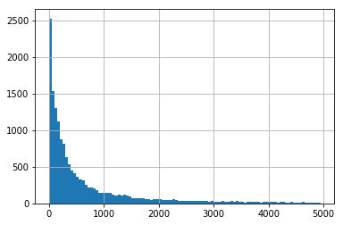

```python
user_artists.groupby("artistID").sum().weight.hist(bins=np.arange(0,5000,50))
```

### 2.) Plot the distribution of unique users playing each artist

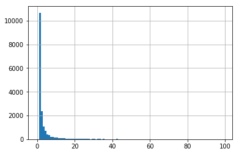

```python
user_artists.groupby("artistID").count().weight.hist(bins=np.arange(0,100,1))
```

### 3.) Plot the distribution of play counts per user

- Note the huge bin sizes

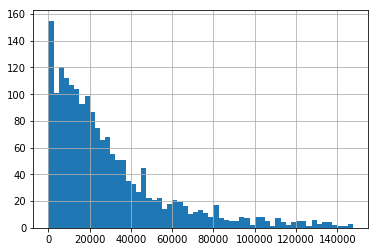

```python
user_artists.groupby("userID").sum().weight.hist(bins=np.arange(0,150000,2500))
```

### 4.) Plot the distribution of unique artists per user

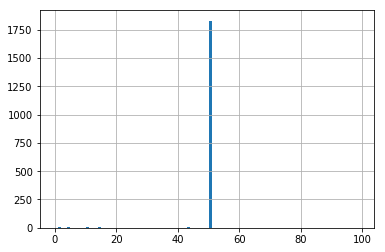

```python
user_artists.groupby("userID").count().artistID.hist(bins=np.arange(0,100,1))
```

### 5.) What is the mean...

- artists-per-user?

```python
user_artists.groupby("userID").count().artistID.mean()
```

```
49.06659619450317
```

- users-per-artist?

```python
user_artists.groupby("artistID").count().userID.mean()
```

```
5.265086206896552
```

- plays per user/artist pair?

```python
user_artists.weight.mean()
```

```
745.2439300256372
```

### 6.) What are the 10 artists with the most plays?

- Need to merge on `artists` using the `artistID` to get the artist names

```python
groups = user_artists.groupby("artistID").sum().sort_values("weight", ascending=False)
groups.merge(artists, left_on="artistID", right_on="id")[["name", "weight"]][:10]
```

|  | name | weight |
| --- | --- | --- |
| 0 | Britney Spears | 2393140 |
| 1 | Depeche Mode | 1301308 |
| 2 | Lady Gaga | 1291387 |
| 3 | Christina Aguilera | 1058405 |
| 4 | Paramore | 963449 |
| 5 | Madonna | 921198 |
| 6 | Rihanna | 905423 |
| 7 | Shakira | 688529 |
| 8 | The Beatles | 662116 |
| 9 | Katy Perry | 532545 |

### 7.) What are the 10 artists with the most unique playing users?

- userID has the number of unique users (could also rename column)

```python
group = user_artists.groupby("artistID").count().sort_values("userID", ascending=False)
group.merge(artists, left_on="artistID", right_on="id")[["name", "userID"]][:10]
```

|  | name | userID |
| --- | --- | --- |
| 0 | Lady Gaga | 611 |
| 1 | Britney Spears | 522 |
| 2 | Rihanna | 484 |
| 3 | The Beatles | 480 |
| 4 | Katy Perry | 473 |
| 5 | Madonna | 429 |
| 6 | Avril Lavigne | 417 |
| 7 | Christina Aguilera | 407 |
| 8 | Muse | 400 |
| 9 | Paramore | 399 |

## Linear regression

- Borrowed from Parker's submission
- As we are trying to fit the regression line, there is no need to split train/test (moreover, linear regression isn't used for classification anyway)

```python
user_friends = pd.read_csv("data/user_friends.dat", delimiter='\t', encoding="ISO-8859-1")
user_friends[:5]
```

|  | userID | friendID |
| --- | --- | --- |
| 0 | 2 | 275 |
| 1 | 2 | 428 |
| 2 | 2 | 515 |
| 3 | 2 | 761 |
| 4 | 2 | 831 |

```python
friend_counts = user_friends.groupby("userID").count().rename(columns={"friendID": "FriendCount"})
tagged_artist_counts = user_taggedartists.groupby("userID").count().rename(columns={"artistID": "TaggedArtistCount"}).drop(columns=["tagID", "day", "month", "year"])
user_data = tagged_artist_counts.merge(friend_counts, on="userID")
user_data[:5]
```

| userID | TaggedArtistCount | FriendCount |
| --- | --- | --- |
| 2 | 45 | 13 |
| 3 | 56 | 7 |
| 4 | 61 | 10 |
| 5 | 43 | 7 |
| 6 | 14 | 5 |

```python
X = user_data[["FriendCount"]]
y = user_data["TaggedArtistCount"]
X = np.array(X).reshape(-1, 1)
```

```python
from sklearn.linear_model import LinearRegression

linreg = LinearRegression()

linreg.fit(np.array(X).reshape(-1,1), y)
```

```
LinearRegression(copy_X=True, fit_intercept=True, n_jobs=None, normalize=False)
```

```python
print("Y-intercept:", linreg.intercept_)
print("Slope:", linreg.coef_)
```

```
Y-intercept: 90.25280393405217
Slope: [0.61809762]
```

### Correlation

- very easy with pandas!

```python
user_data.corr()
```

|  | TaggedArtistCount | FriendCount |
| --- | --- | --- |
| TaggedArtistCount | 1.000000 | 0.047646 |
| FriendCount | 0.047646 | 1.000000 |

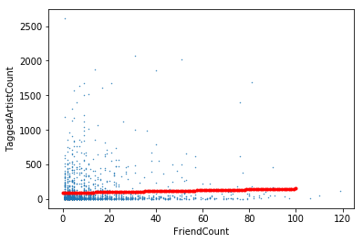

```python
import matplotlib.pyplot as plt

user_data.plot.scatter('FriendCount', 'TaggedArtistCount', s=0.2)
plt.plot(np.linspace(0,100,100), [linreg.intercept_ + linreg.coef_ * z for z in np.linspace(0,100,100)], c="red", marker=".", linestyle=":")
plt.show()
```

We see a *very* mild positive correlation between `FriendCount` (X) and `TaggedArtistCount` (Y). The correlation coeffecient is 0.048 and the best fit line has a Y-intercept=90.25 and slope m=0.618.

In the scatter plot, we see that there are many users that have few tagged artists and many friends, and conversely many users that have few friends and many tagged artists. Friend count is not a good predictor for tagged artist count, and vice versa.